# Airline passenger satisfaction

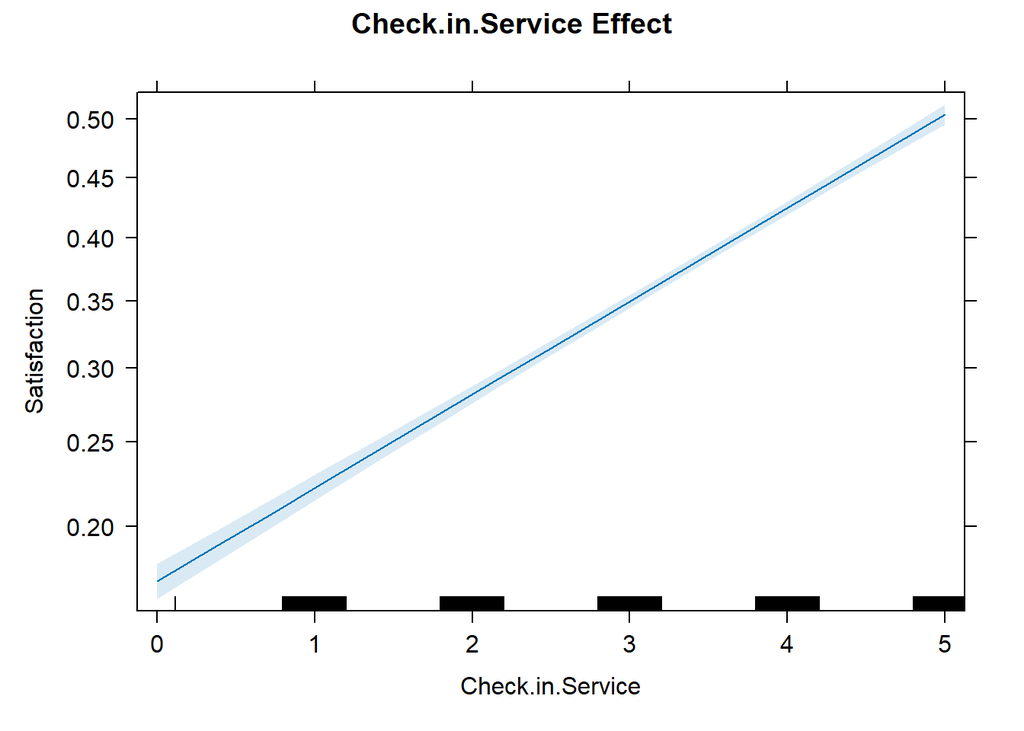

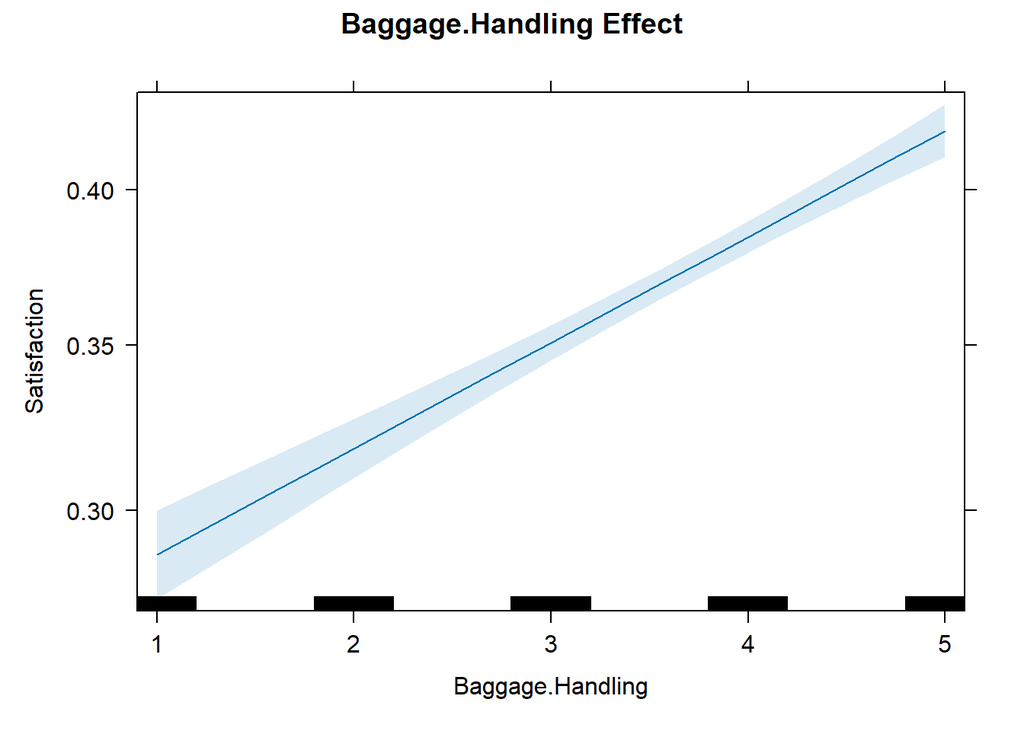

[figure not shown]

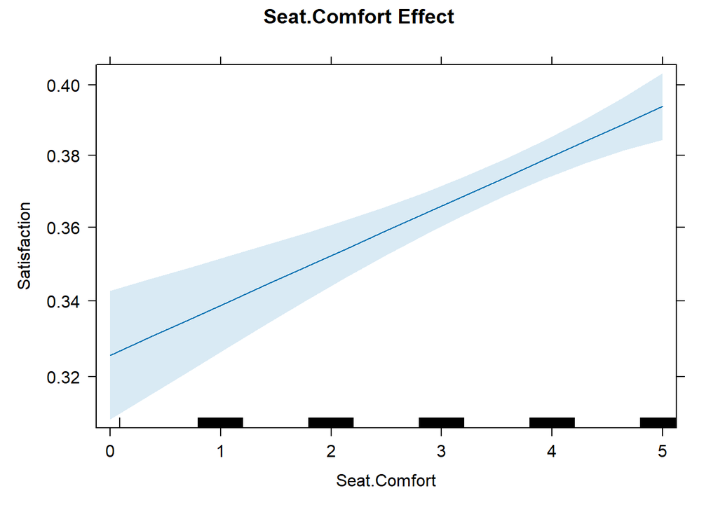

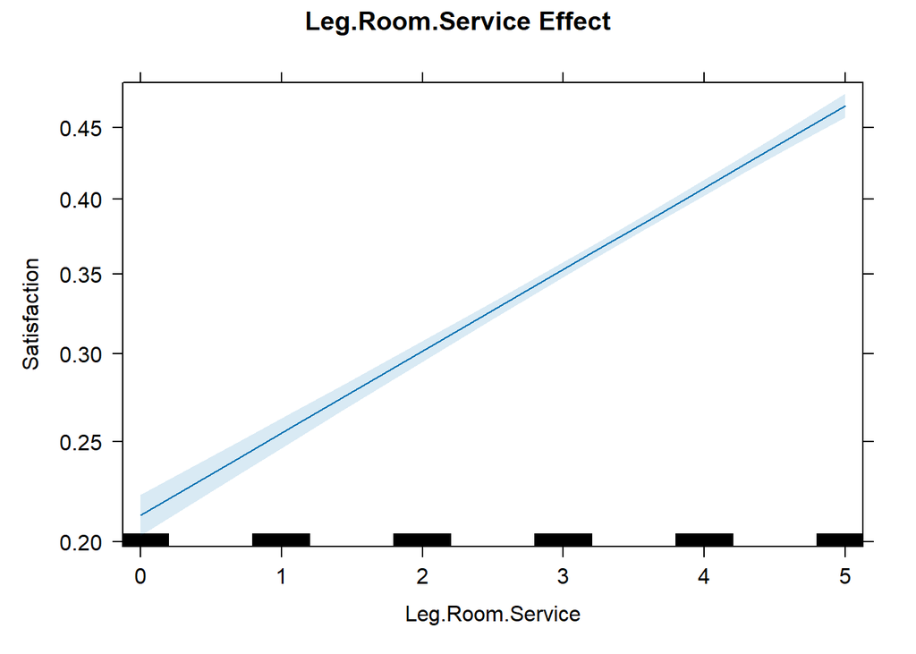

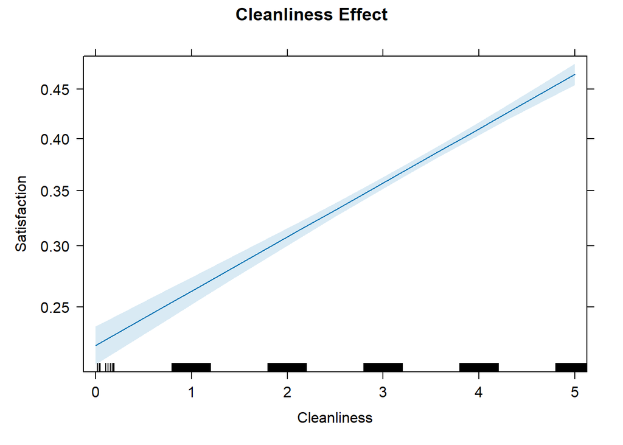

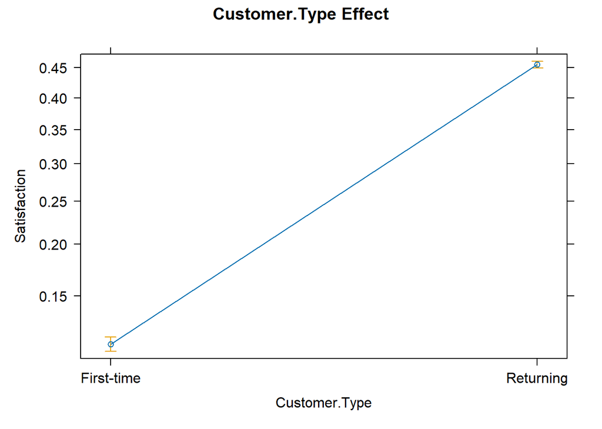

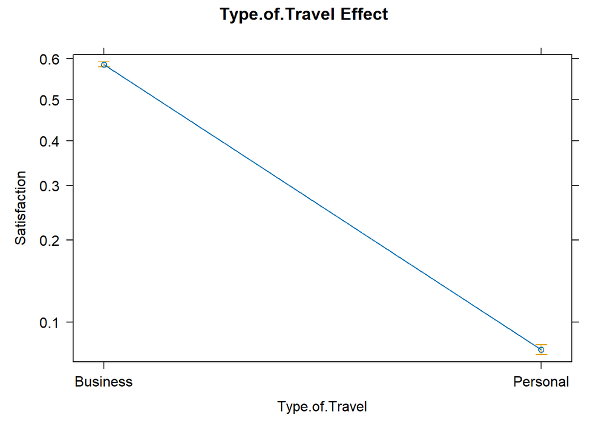

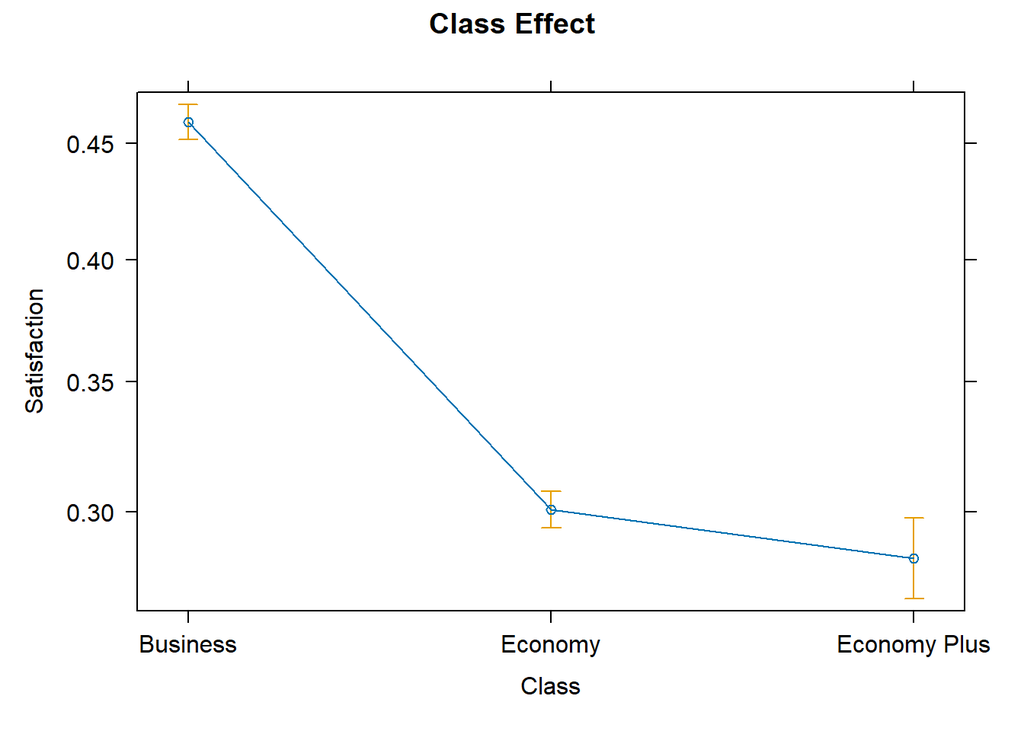

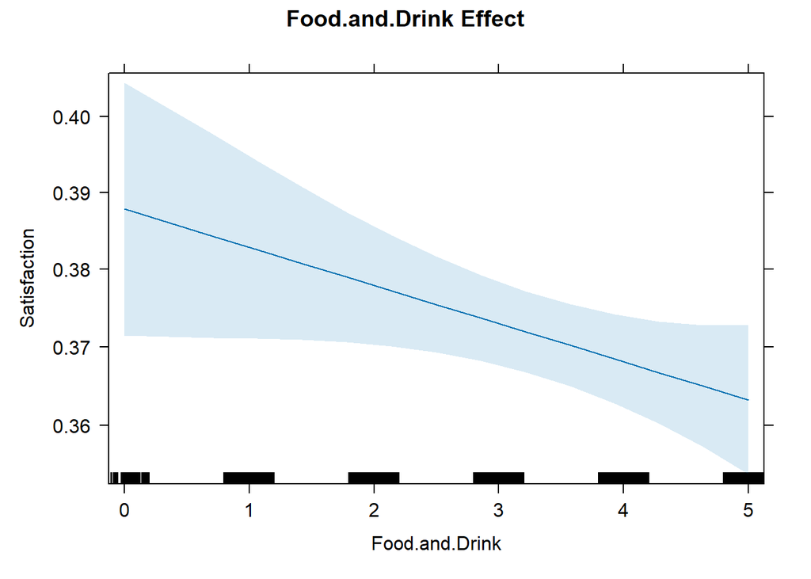

[3 more figures not shown]

## 6.7 Summary of combined results of best model

Below we can analyse the results obtained by merging the previous models. Here is an index to understand the table:

- `AS_CTT_model`: Airport Services + Customer and Travel Type.
- `AS_CC_model`: Airport Services + Comfort and Cleanliness.
- `AS_OBS_models`: Airport Services + On-board Services.
- `AS_CTT_CC_model`: Airport Services + Customer and Travel Type + Comfort and Cleanliness.
- `AS_CTT_OBS_model`: Airport Services + Customer and Travel Type + On-board Services.
- `Complete_model`: Airport Services + Customer and Travel Type + Comfort and Cleanliness + On-board Services.

```
##              Model      AIC       AUC Threshold.Accuracy.0.5 Best.Threshold
## 1     AS_CTT_model 74708.43 0.9158880                  0.858          0.862
## 2     TAS_CC_model 95898.93 0.8621074                  0.806          0.806
## 3    AS_OBS_models 97433.86 0.8606656                  0.807          0.807
## 4  AS_CTT_CC_model 71873.02 0.9200799                  0.866          0.866
## 5 AS_CTT_OBS_model 71766.01 0.9227770                  0.869          0.869
## 6   Complete_model 70549.63 0.9246157                  0.872          0.872
##   N.of.predictors
## 1               8
## 2               8
## 3               9
## 4              11
## 5              12
## 6              15
```

By combining the previously created classes together, we can see how the results are improved compared to using a single class. The airport service class is always used as it is the best taken individually. What we can analyse is that the best model is the one that uses all 4 classes. We can therefore understand that to efficiently evaluate customer satisfaction we mainly need the services offered by the airport, if they are good the probability of having a satisfied customer goes up. This is also the case for the other classes; positive ratings of on-board services lead to a higher probability of being satisfied, this also applies to comfort and cleanliness. Finally, positive or negative passenger satisfaction also depends on the type of class chosen and the type of journey. Choosing business class leads to an increase in services and comfort on board and therefore a greater likelihood of satisfaction, while economy class may lead to lower satisfaction due to less comfort and services.

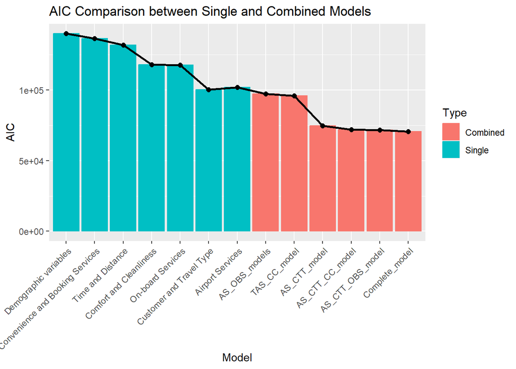

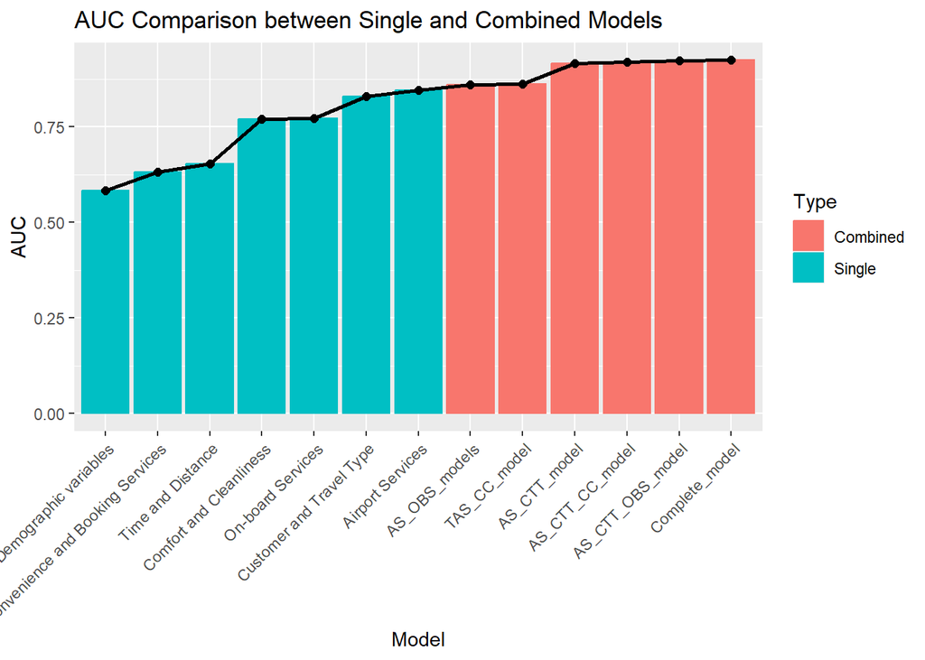

Here we can see how the results of the models improve by combining the individual models together. For the AIC, we see that combining the models decreases the value of the AIC. The best model is the one that combines the individual models. For the auc on the other hand we can see the same improvement, the combination of the models leads to an increase in the final value and thus to a better result for the final prediction.

Final conclusions will be included in the final chapter.

# 7 Stepwise Regression models

In this section I am going to implement the stepwise regression model using three different modes: forward, backward and both.

```r
null_model <- glm(Satisfaction ~ 1, data = train, family = binomial)
full_model <- glm(Satisfaction ~ ., data = train, family = binomial)
summary(full_model)
```

```
##
## Call:
## glm(formula = Satisfaction ~ ., family = binomial, data = train)
##
## Coefficients:
##                                          Estimate Std. Error z value Pr(>|z|)
## (Intercept)                            -7.847e+00  7.877e-02 -99.616  < 2e-16
## GenderMale                              6.565e-02  1.946e-02   3.374 0.000741
## Age                                    -8.315e-03  7.109e-04 -11.697  < 2e-16
## Customer.TypeReturning                  2.031e+00  2.985e-02  68.043  < 2e-16
## Type.of.TravelPersonal                 -2.716e+00  3.141e-02 -86.481  < 2e-16
## ClassEconomy                           -7.127e-01  2.562e-02 -27.816  < 2e-16
## ClassEconomy Plus                      -8.083e-01  4.138e-02 -19.533  < 2e-16
## Flight.Distance                        -9.633e-06  1.127e-05  -0.855 0.392651
## Departure.and.Arrival.Time.Convenience -1.365e-01  8.184e-03 -16.676  < 2e-16
## Ease.of.Online.Booking                 -1.481e-01  1.129e-02 -13.116  < 2e-16
## Check.in.Service                        3.284e-01  8.553e-03  38.400  < 2e-16
## Online.Boarding                         6.105e-01  1.024e-02  59.646  < 2e-16
## Gate.Location                           2.552e-02  9.184e-03   2.779 0.005457
## On.board.Service                        2.929e-01  1.020e-02  28.714  < 2e-16
## Seat.Comfort                            6.539e-02  1.119e-02   5.843 5.14e-09
## Leg.Room.Service                        2.484e-01  8.521e-03  29.154  < 2e-16
## Cleanliness                             2.233e-01  1.209e-02  18.468  < 2e-16
## Food.and.Drink                         -2.977e-02  1.071e-02  -2.780 0.005439
## In.flight.Service                       1.166e-01  1.205e-02   9.677  < 2e-16
## In.flight.Wifi.Service                  4.031e-01  1.144e-02  35.228  < 2e-16
## In.flight.Entertainment                 6.215e-02  1.423e-02   4.367 1.26e-05
## Baggage.Handling                        1.484e-01  1.143e-02  12.987  < 2e-16
## Delay                                  -4.979e-03  2.684e-04 -18.546  < 2e-16
##
## (Intercept)                            ***
## GenderMale                             ***
## Age                                    ***
## Customer.TypeReturning                 ***
## Type.of.TravelPersonal                 ***
## ClassEconomy                           ***
## ClassEconomy Plus                      ***
## Flight.Distance
## Departure.and.Arrival.Time.Convenience ***
## Ease.of.Online.Booking                 ***
```

[output cut: 8 more lines]

```
## In.flight.Service                      ***
## In.flight.Wifi.Service                 ***
## In.flight.Entertainment                ***
## Baggage.Handling                       ***
## Delay                                  ***
## ---
## Signif. codes:  0 '***' 0.001 '**' 0.01 '*' 0.05 '.' 0.1 ' ' 1
##
## (Dispersion parameter for binomial family taken to be 1)
##
##     Null deviance: 141833  on 103611  degrees of freedom
## Residual deviance:  69400  on 103589  degrees of freedom
## AIC: 69446
##
## Number of Fisher Scoring iterations: 5
```

## 7.1 Forward

```r
stepwise_model_forward <- step(null_model, scope = list(lower = null_model, upper = full_model), direction = "forward")
```

```
## Start:  AIC=141835.2
## Satisfaction ~ 1
##
##                                          Df Deviance    AIC
## + Online.Boarding                         1   111866 111870
## + Class                                   2   114373 114379
## + Type.of.Travel                          1   118175 118179
## + In.flight.Entertainment                 1   124047 124051
## + Seat.Comfort                            1   128375 128379
## + On.board.Service                        1   130620 130624
## + Leg.Room.Service                        1   131227 131231
## + Cleanliness                             1   131668 131672
## + Flight.Distance                         1   132314 132318
## + In.flight.Wifi.Service                  1   133215 133219
## + Baggage.Handling                        1   135111 135115
## + In.flight.Service                       1   135421 135425
## + Check.in.Service                        1   135817 135821
## + Food.and.Drink                          1   137077 137081
## + Customer.Type                           1   138001 138005
## + Ease.of.Online.Booking                  1   138830 138834
## + Age                                     1   139940 139944
## + Departure.and.Arrival.Time.Convenience  1   141514 141518
## + Delay                                   1   141528 141532
## + Gender                                  1   141820 141824
## <none>                                        141833 141835
## + Gate.Location                           1   141832 141836
##
## Step:  AIC=111870.2
## Satisfaction ~ Online.Boarding
##
##                                          Df Deviance    AIC
## + Type.of.Travel                          1    93786  93792
## + Class                                   2    95650  95658
## + In.flight.Entertainment                 1   102223 102229
## + Leg.Room.Service                        1   103128 103134
## + On.board.Service                        1   103787 103793
## + Baggage.Handling                        1   106195 106201
## + In.flight.Service                       1   106234 106240
## + Flight.Distance                         1   106775 106781
## + Seat.Comfort                            1   109048 109054
```

[output cut: 349 more lines]

```
## + Food.and.Drink   1    69401 69445
## <none>                  69408 69450
## + Flight.Distance  1    69408 69452
##
## Step:  AIC=69444.72
## Satisfaction ~ Online.Boarding + Type.of.Travel + On.board.Service +
##     Customer.Type + Check.in.Service + In.flight.Entertainment +
##     Leg.Room.Service + Class + In.flight.Wifi.Service + Departure.and.Arrival.Time.Convenience +
##     Cleanliness + Delay + Baggage.Handling + Ease.of.Online.Booking +
##     Age + In.flight.Service + Seat.Comfort + Gender + Gate.Location +
##     Food.and.Drink
##
##                   Df Deviance   AIC
## <none>                  69401 69445
## + Flight.Distance  1    69400 69446
```

```r
summary(stepwise_model_forward)
```

```
##
## Call:
## glm(formula = Satisfaction ~ Online.Boarding + Type.of.Travel +
##     On.board.Service + Customer.Type + Check.in.Service + In.flight.Entertainment +
##     Leg.Room.Service + Class + In.flight.Wifi.Service + Departure.and.Arrival.Time.Convenience +
##     Cleanliness + Delay + Baggage.Handling + Ease.of.Online.Booking +
##     Age + In.flight.Service + Seat.Comfort + Gender + Gate.Location +
##     Food.and.Drink, family = binomial, data = train)
##
## Coefficients:
##                                          Estimate Std. Error  z value Pr(>|z|)
## (Intercept)                            -7.8578499  0.0776750 -101.163  < 2e-16
## Online.Boarding                         0.6102502  0.0102313   59.646  < 2e-16
## Type.of.TravelPersonal                 -2.7129786  0.0311950  -86.968  < 2e-16
## On.board.Service                        0.2928081  0.0101986   28.711  < 2e-16
## Customer.TypeReturning                  2.0246679  0.0287986   70.304  < 2e-16
## Check.in.Service                        0.3283798  0.0085524   38.396  < 2e-16
## In.flight.Entertainment                 0.0621032  0.0142319    4.364 1.28e-05
## Leg.Room.Service                        0.2481733  0.0085153   29.144  < 2e-16
## ClassEconomy                           -0.7059078  0.0243541  -28.985  < 2e-16
## ClassEconomy Plus                      -0.8001515  0.0402643  -19.872  < 2e-16
## In.flight.Wifi.Service                  0.4036683  0.0114282   35.322  < 2e-16
## Departure.and.Arrival.Time.Convenience -0.1365724  0.0081825  -16.691  < 2e-16
## Cleanliness                             0.2232452  0.0120906   18.464  < 2e-16
## Delay                                  -0.0049798  0.0002685  -18.549  < 2e-16
## Baggage.Handling                        0.1484919  0.0114237   12.999  < 2e-16
## Ease.of.Online.Booking                 -0.1483120  0.0112942  -13.132  < 2e-16
## Age                                    -0.0082749  0.0007093  -11.666  < 2e-16
## In.flight.Service                       0.1167544  0.0120433    9.695  < 2e-16
## Seat.Comfort                            0.0652143  0.0111898    5.828 5.61e-09
## GenderMale                              0.0656675  0.0194577    3.375 0.000738
## Gate.Location                           0.0256015  0.0091832    2.788 0.005306
## Food.and.Drink                         -0.0296153  0.0107092   -2.765 0.005685
##
## (Intercept)                            ***
## Online.Boarding                        ***
## Type.of.TravelPersonal                 ***
## On.board.Service                       ***
## Customer.TypeReturning                 ***
## Check.in.Service                       ***
```

[output cut: 11 more lines]

```
## In.flight.Service                      ***
## Seat.Comfort                           ***
## GenderMale                             ***
## Gate.Location                          **
## Food.and.Drink                         **
## ---
## Signif. codes:  0 '***' 0.001 '**' 0.01 '*' 0.05 '.' 0.1 ' ' 1
##
## (Dispersion parameter for binomial family taken to be 1)
##
##     Null deviance: 141833  on 103611  degrees of freedom
## Residual deviance:  69401  on 103590  degrees of freedom
## AIC: 69445
##
## Number of Fisher Scoring iterations: 5
```

Below i run a test using the test set of mine dataset to see the capacity of the model:

```r
stepwise_model_forward_probs <- predict(stepwise_model_forward, testX, type = "response")

stepwise_model_forward_roc <- roc(test$Satisfaction ~ stepwise_model_forward_probs, plot=TRUE, print.auc=TRUE)
coords(stepwise_model_forward_roc, x=0.5, ret="all")
```

[output not shown]

```
##           threshold specificity sensitivity  accuracy    tn   tp   fn   fp
## threshold       0.5   0.9088667   0.8315752 0.8751691 13264 9381 1900 1330
##                 npv       ppv       fdr        fpr       tpr       tnr
## threshold 0.8747032 0.8758286 0.1241714 0.09113334 0.8315752 0.9088667
##                 fnr 1-specificity 1-sensitivity 1-accuracy     1-npv     1-ppv
## threshold 0.1684248    0.09113334     0.1684248  0.1248309 0.1252968 0.1241714
##           precision    recall   youden closest.topleft
## threshold 0.8758286 0.8315752 1.740442      0.03667219
```

And the following considering the best threshold:

```r
coords(stepwise_model_forward_roc, x="best", ret="all")
```

```
##           threshold specificity sensitivity  accuracy    tn   tp   fn   fp
## threshold 0.4739646     0.90037   0.8407943 0.8743961 13140 9485 1796 1454
##                 npv       ppv       fdr        fpr       tpr     tnr       fnr
## threshold 0.8797536 0.8670811 0.1329189 0.09962998 0.8407943 0.90037 0.1592057
##           1-specificity 1-sensitivity 1-accuracy     1-npv     1-ppv precision
## threshold    0.09962998     0.1592057  0.1256039 0.1202464 0.1329189 0.8670811
##              recall   youden closest.topleft
## threshold 0.8407943 1.741164       0.0352726
```

## 7.2 Backward

```r
stepwise_model_backward <- step(full_model, scope = list(lower = null_model, upper = full_model), direction = "backward")
```

```
## Start:  AIC=69445.99
## Satisfaction ~ Gender + Age + Customer.Type + Type.of.Travel +
##     Class + Flight.Distance + Departure.and.Arrival.Time.Convenience +
##     Ease.of.Online.Booking + Check.in.Service + Online.Boarding +
##     Gate.Location + On.board.Service + Seat.Comfort + Leg.Room.Service +
##     Cleanliness + Food.and.Drink + In.flight.Service + In.flight.Wifi.Service +
##     In.flight.Entertainment + Baggage.Handling + Delay
##
##                                          Df Deviance   AIC
## - Flight.Distance                         1    69401 69445
## <none>                                         69400 69446
## - Gate.Location                           1    69408 69452
## - Food.and.Drink                          1    69408 69452
## - Gender                                  1    69411 69455
## - In.flight.Entertainment                 1    69419 69463
## - Seat.Comfort                            1    69434 69478
## - In.flight.Service                       1    69494 69538
## - Age                                     1    69538 69582
## - Baggage.Handling                        1    69570 69614
## - Ease.of.Online.Booking                  1    69573 69617
## - Departure.and.Arrival.Time.Convenience  1    69677 69721
## - Cleanliness                             1    69743 69787
## - Delay                                   1    69766 69810
## - On.board.Service                        1    70239 70283
## - Leg.Room.Service                        1    70255 70299
## - Class                                   2    70271 70313
## - In.flight.Wifi.Service                  1    70685 70729
## - Check.in.Service                        1    70925 70969
## - Online.Boarding                         1    73182 73226
## - Customer.Type                           1    74486 74530
## - Type.of.Travel                          1    78184 78228
##
## Step:  AIC=69444.72
## Satisfaction ~ Gender + Age + Customer.Type + Type.of.Travel +
##     Class + Departure.and.Arrival.Time.Convenience + Ease.of.Online.Booking +
##     Check.in.Service + Online.Boarding + Gate.Location + On.board.Service +
##     Seat.Comfort + Leg.Room.Service + Cleanliness + Food.and.Drink +
##     In.flight.Service + In.flight.Wifi.Service + In.flight.Entertainment +
##     Baggage.Handling + Delay
##
##                                          Df Deviance   AIC
## <none>                                         69401 69445
## - Food.and.Drink                          1    69408 69450
## - Gate.Location                           1    69408 69450
## - Gender                                  1    69412 69454
## - In.flight.Entertainment                 1    69420 69462
## - Seat.Comfort                            1    69435 69477
## - In.flight.Service                       1    69495 69537
## - Age                                     1    69538 69580
## - Baggage.Handling                        1    69571 69613
## - Ease.of.Online.Booking                  1    69574 69616
## - Departure.and.Arrival.Time.Convenience  1    69678 69720
## - Cleanliness                             1    69744 69786
## - Delay                                   1    69767 69809
## - On.board.Service                        1    70239 70281
## - Leg.Room.Service                        1    70255 70297
## - Class                                   2    70363 70403
## - In.flight.Wifi.Service                  1    70692 70734
## - Check.in.Service                        1    70926 70968
## - Online.Boarding                         1    73183 73225
## - Customer.Type                           1    74830 74872
## - Type.of.Travel                          1    78311 78353
```

```r
summary(stepwise_model_backward)
```

```
##
## Call:
## glm(formula = Satisfaction ~ Gender + Age + Customer.Type + Type.of.Travel +
##     Class + Departure.and.Arrival.Time.Convenience + Ease.of.Online.Booking +
##     Check.in.Service + Online.Boarding + Gate.Location + On.board.Service +
##     Seat.Comfort + Leg.Room.Service + Cleanliness + Food.and.Drink +
##     In.flight.Service + In.flight.Wifi.Service + In.flight.Entertainment +
##     Baggage.Handling + Delay, family = binomial, data = train)
##
## Coefficients:
##                                          Estimate Std. Error  z value Pr(>|z|)
## (Intercept)                            -7.8578499  0.0776750 -101.163  < 2e-16
## GenderMale                              0.0656675  0.0194577    3.375 0.000738
## Age                                    -0.0082749  0.0007093  -11.666  < 2e-16
## Customer.TypeReturning                  2.0246679  0.0287986   70.304  < 2e-16
## Type.of.TravelPersonal                 -2.7129786  0.0311950  -86.968  < 2e-16
## ClassEconomy                           -0.7059078  0.0243541  -28.985  < 2e-16
## ClassEconomy Plus                      -0.8001515  0.0402643  -19.872  < 2e-16
## Departure.and.Arrival.Time.Convenience -0.1365724  0.0081825  -16.691  < 2e-16
## Ease.of.Online.Booking                 -0.1483120  0.0112942  -13.132  < 2e-16
## Check.in.Service                        0.3283798  0.0085524   38.396  < 2e-16
## Online.Boarding                         0.6102502  0.0102313   59.646  < 2e-16
## Gate.Location                           0.0256015  0.0091832    2.788 0.005306
## On.board.Service                        0.2928081  0.0101986   28.711  < 2e-16
## Seat.Comfort                            0.0652143  0.0111898    5.828 5.61e-09
## Leg.Room.Service                        0.2481733  0.0085153   29.144  < 2e-16
## Cleanliness                             0.2232452  0.0120906   18.464  < 2e-16
## Food.and.Drink                         -0.0296153  0.0107092   -2.765 0.005685
## In.flight.Service                       0.1167544  0.0120433    9.695  < 2e-16
## In.flight.Wifi.Service                  0.4036683  0.0114282   35.322  < 2e-16
## In.flight.Entertainment                 0.0621032  0.0142319    4.364 1.28e-05
## Baggage.Handling                        0.1484919  0.0114237   12.999  < 2e-16
## Delay                                  -0.0049798  0.0002685  -18.549  < 2e-16
##
## (Intercept)                            ***
## GenderMale                             ***
## Age                                    ***
## Customer.TypeReturning                 ***
## Type.of.TravelPersonal                 ***
## ClassEconomy                           ***
```

[output cut: 11 more lines]

```
## In.flight.Service                      ***
## In.flight.Wifi.Service                 ***
## In.flight.Entertainment                ***
## Baggage.Handling                       ***
## Delay                                  ***
## ---
## Signif. codes:  0 '***' 0.001 '**' 0.01 '*' 0.05 '.' 0.1 ' ' 1
##
## (Dispersion parameter for binomial family taken to be 1)
##
##     Null deviance: 141833  on 103611  degrees of freedom
## Residual deviance:  69401  on 103590  degrees of freedom
## AIC: 69445
##
## Number of Fisher Scoring iterations: 5
```

```r
stepwise_model_backward_probs <- predict(stepwise_model_backward, testX, type = "response")

stepwise_model_backward_roc <- roc(test$Satisfaction ~ stepwise_model_backward_probs, plot=TRUE, print.auc=TRUE)
```

[output not shown]

roc function reports the following results with a threshold of 0.5:

```r
coords(stepwise_model_backward_roc, x=0.5, ret="all")
```

```
##           threshold specificity sensitivity  accuracy    tn   tp   fn   fp
## threshold       0.5   0.9088667   0.8315752 0.8751691 13264 9381 1900 1330
##                 npv       ppv       fdr        fpr       tpr       tnr
## threshold 0.8747032 0.8758286 0.1241714 0.09113334 0.8315752 0.9088667
##                 fnr 1-specificity 1-sensitivity 1-accuracy     1-npv     1-ppv
## threshold 0.1684248    0.09113334     0.1684248  0.1248309 0.1252968 0.1241714
##           precision    recall   youden closest.topleft
## threshold 0.8758286 0.8315752 1.740442      0.03667219
```

And the following considering the best threshold:

```r
coords(stepwise_model_backward_roc, x="best", ret="all")
```

```
##           threshold specificity sensitivity  accuracy    tn   tp   fn   fp
## threshold 0.4739646     0.90037   0.8407943 0.8743961 13140 9485 1796 1454
##                 npv       ppv       fdr        fpr       tpr     tnr       fnr
## threshold 0.8797536 0.8670811 0.1329189 0.09962998 0.8407943 0.90037 0.1592057
##           1-specificity 1-sensitivity 1-accuracy     1-npv     1-ppv precision
## threshold    0.09962998     0.1592057  0.1256039 0.1202464 0.1329189 0.8670811
##              recall   youden closest.topleft
## threshold 0.8407943 1.741164       0.0352726
```

## 7.3 Both

```r
stepwise_model_both <- step(full_model, scope = list(lower = null_model, upper = full_model), direction = "both")
```

```
## Start:  AIC=69445.99
## Satisfaction ~ Gender + Age + Customer.Type + Type.of.Travel +
##     Class + Flight.Distance + Departure.and.Arrival.Time.Convenience +
##     Ease.of.Online.Booking + Check.in.Service + Online.Boarding +
##     Gate.Location + On.board.Service + Seat.Comfort + Leg.Room.Service +
##     Cleanliness + Food.and.Drink + In.flight.Service + In.flight.Wifi.Service +
##     In.flight.Entertainment + Baggage.Handling + Delay
##
##                                          Df Deviance   AIC
## - Flight.Distance                         1    69401 69445
## <none>                                         69400 69446
## - Gate.Location                           1    69408 69452
## - Food.and.Drink                          1    69408 69452
## - Gender                                  1    69411 69455
## - In.flight.Entertainment                 1    69419 69463
## - Seat.Comfort                            1    69434 69478
## - In.flight.Service                       1    69494 69538
## - Age                                     1    69538 69582
## - Baggage.Handling                        1    69570 69614
## - Ease.of.Online.Booking                  1    69573 69617
## - Departure.and.Arrival.Time.Convenience  1    69677 69721
## - Cleanliness                             1    69743 69787
## - Delay                                   1    69766 69810
## - On.board.Service                        1    70239 70283
## - Leg.Room.Service                        1    70255 70299
## - Class                                   2    70271 70313
## - In.flight.Wifi.Service                  1    70685 70729
## - Check.in.Service                        1    70925 70969
## - Online.Boarding                         1    73182 73226
## - Customer.Type                           1    74486 74530
## - Type.of.Travel                          1    78184 78228
##
## Step:  AIC=69444.72
## Satisfaction ~ Gender + Age + Customer.Type + Type.of.Travel +
##     Class + Departure.and.Arrival.Time.Convenience + Ease.of.Online.Booking +
##     Check.in.Service + Online.Boarding + Gate.Location + On.board.Service +
##     Seat.Comfort + Leg.Room.Service + Cleanliness + Food.and.Drink +
##     In.flight.Service + In.flight.Wifi.Service + In.flight.Entertainment +
##     Baggage.Handling + Delay
##
```

[output cut: 8 more lines]

```
## - In.flight.Service                       1    69495 69537
## - Age                                     1    69538 69580
## - Baggage.Handling                        1    69571 69613
## - Ease.of.Online.Booking                  1    69574 69616
## - Departure.and.Arrival.Time.Convenience  1    69678 69720
## - Cleanliness                             1    69744 69786
## - Delay                                   1    69767 69809
## - On.board.Service                        1    70239 70281
## - Leg.Room.Service                        1    70255 70297
## - Class                                   2    70363 70403
## - In.flight.Wifi.Service                  1    70692 70734
## - Check.in.Service                        1    70926 70968
## - Online.Boarding                         1    73183 73225
## - Customer.Type                           1    74830 74872
## - Type.of.Travel                          1    78311 78353
```

```r
summary(stepwise_model_both)
```

```
##
## Call:
## glm(formula = Satisfaction ~ Gender + Age + Customer.Type + Type.of.Travel +
##     Class + Departure.and.Arrival.Time.Convenience + Ease.of.Online.Booking +
##     Check.in.Service + Online.Boarding + Gate.Location + On.board.Service +
##     Seat.Comfort + Leg.Room.Service + Cleanliness + Food.and.Drink +
##     In.flight.Service + In.flight.Wifi.Service + In.flight.Entertainment +
##     Baggage.Handling + Delay, family = binomial, data = train)
##
## Coefficients:
##                                          Estimate Std. Error  z value Pr(>|z|)
## (Intercept)                            -7.8578499  0.0776750 -101.163  < 2e-16
## GenderMale                              0.0656675  0.0194577    3.375 0.000738
## Age                                    -0.0082749  0.0007093  -11.666  < 2e-16
## Customer.TypeReturning                  2.0246679  0.0287986   70.304  < 2e-16
## Type.of.TravelPersonal                 -2.7129786  0.0311950  -86.968  < 2e-16
## ClassEconomy                           -0.7059078  0.0243541  -28.985  < 2e-16
## ClassEconomy Plus                      -0.8001515  0.0402643  -19.872  < 2e-16
## Departure.and.Arrival.Time.Convenience -0.1365724  0.0081825  -16.691  < 2e-16
## Ease.of.Online.Booking                 -0.1483120  0.0112942  -13.132  < 2e-16
## Check.in.Service                        0.3283798  0.0085524   38.396  < 2e-16
## Online.Boarding                         0.6102502  0.0102313   59.646  < 2e-16
## Gate.Location                           0.0256015  0.0091832    2.788 0.005306
## On.board.Service                        0.2928081  0.0101986   28.711  < 2e-16
## Seat.Comfort                            0.0652143  0.0111898    5.828 5.61e-09
## Leg.Room.Service                        0.2481733  0.0085153   29.144  < 2e-16
## Cleanliness                             0.2232452  0.0120906   18.464  < 2e-16
## Food.and.Drink                         -0.0296153  0.0107092   -2.765 0.005685
## In.flight.Service                       0.1167544  0.0120433    9.695  < 2e-16
## In.flight.Wifi.Service                  0.4036683  0.0114282   35.322  < 2e-16
## In.flight.Entertainment                 0.0621032  0.0142319    4.364 1.28e-05
## Baggage.Handling                        0.1484919  0.0114237   12.999  < 2e-16
## Delay                                  -0.0049798  0.0002685  -18.549  < 2e-16
##
## (Intercept)                            ***
## GenderMale                             ***
## Age                                    ***
## Customer.TypeReturning                 ***
## Type.of.TravelPersonal                 ***
## ClassEconomy                           ***
```

[output cut: 11 more lines]

```
## In.flight.Service                      ***
## In.flight.Wifi.Service                 ***
## In.flight.Entertainment                ***
## Baggage.Handling                       ***
## Delay                                  ***
## ---
## Signif. codes:  0 '***' 0.001 '**' 0.01 '*' 0.05 '.' 0.1 ' ' 1
##
## (Dispersion parameter for binomial family taken to be 1)
##
##     Null deviance: 141833  on 103611  degrees of freedom
## Residual deviance:  69401  on 103590  degrees of freedom
## AIC: 69445
##
## Number of Fisher Scoring iterations: 5
```

```r
stepwise_model_both_probs <- predict(stepwise_model_both, testX, type = "response")

stepwise_model_both_roc <- roc(test$Satisfaction ~ stepwise_model_both_probs, plot=TRUE, print.auc=TRUE)
```

[output not shown]

roc function reports the following results with a threshold of 0.5:

```r
coords(stepwise_model_backward_roc, x=0.5, ret="all")
```

```
##           threshold specificity sensitivity  accuracy    tn   tp   fn   fp
## threshold       0.5   0.9088667   0.8315752 0.8751691 13264 9381 1900 1330
##                 npv       ppv       fdr        fpr       tpr       tnr
## threshold 0.8747032 0.8758286 0.1241714 0.09113334 0.8315752 0.9088667
##                 fnr 1-specificity 1-sensitivity 1-accuracy     1-npv     1-ppv
## threshold 0.1684248    0.09113334     0.1684248  0.1248309 0.1252968 0.1241714
##           precision    recall   youden closest.topleft
## threshold 0.8758286 0.8315752 1.740442      0.03667219
```

And the following considering the best threshold:

```r
coords(stepwise_model_backward_roc, x="best", ret="all")
```

```
##           threshold specificity sensitivity  accuracy    tn   tp   fn   fp
## threshold 0.4739646     0.90037   0.8407943 0.8743961 13140 9485 1796 1454
##                 npv       ppv       fdr        fpr       tpr     tnr       fnr
## threshold 0.8797536 0.8670811 0.1329189 0.09962998 0.8407943 0.90037 0.1592057
##           1-specificity 1-sensitivity 1-accuracy     1-npv     1-ppv precision
## threshold    0.09962998     0.1592057  0.1256039 0.1202464 0.1329189 0.8670811
##              recall   youden closest.topleft
## threshold 0.8407943 1.741164       0.0352726
```

## 7.4 Summary of stepwise results

Below is a table summarising all the results of previous models:

```
##               Model      AIC       AUC Threshold.Accuracy.0.5 Best.Threshold
## 1  stepwise forward 69444.72 0.9263077                  0.875          0.874
## 2 stepwise backward 69444.72 0.9263077                  0.875          0.874
## 3     stepwise both 69444.72 0.9263077                  0.875          0.874
##   Number.of.predictors
## 1                   21
## 2                   21
## 3                   21
```

We can see that the results obtained from the 3 models are the same. This means that the relevant predictors are well defined regardless of the model used, so the models converge to the same set of predictors. Consequently, all predictors chosen by the models are relevant for the prediction of passenger satisfaction.

The final conclusion is that the models are very stable in this context and tend to converge to the same optimal model.

These results do not indicate that the best solution is the one obtained. As we have seen above, in order to obtain a good satisfaction prediction model, we can also select a number of best predictors that are concentrated in certain classes.

# 8 Shrinkage Methods

Shrinkage methods are widely used in statistical modelling to reduce overfitting and improve model performance, especially when dealing with a large number of predictors. These methods work by applying a regularisation technique to reduce coefficient estimates towards zero.

Bias: when the model is too simple, it can under-fit the data, causing a high bias. Narrowing the coefficients towards zero increases the bias. Variance: When the model is too complex, it can over-fit the data, capturing noise and irrelevant patterns, resulting in high variance. Reducing the coefficients reduces variance by discouraging complex models with high coefficients. The goal is to find the optimal balance between bias and variance that minimises the mean square error. The mean square error is the sum of the squared differences between observed and predicted values.

The most common shrinkage methods:

- ridge regression
- lasso

Ridge regression adds a penalty to the sum of the squared coefficients (L2 penalty). It reduces the coefficients but never completely zeroes them, which means that all predictors are retained in the model.

Lasso adds a penalty to the sum of the absolute values of the coefficients (penalty L1). In contrast to the ridge regression, Lasso can reduce some coefficients to exactly zero, effectively making a selection of variables by excluding unimportant predictors.

## 8.1 Lasso model

We use Lasso to evaluate the best parameters. We use cross validation to calculate the best lambda value to be used in the model. The Lasso model is based on calculating the sum of the absolute values of the coefficients.

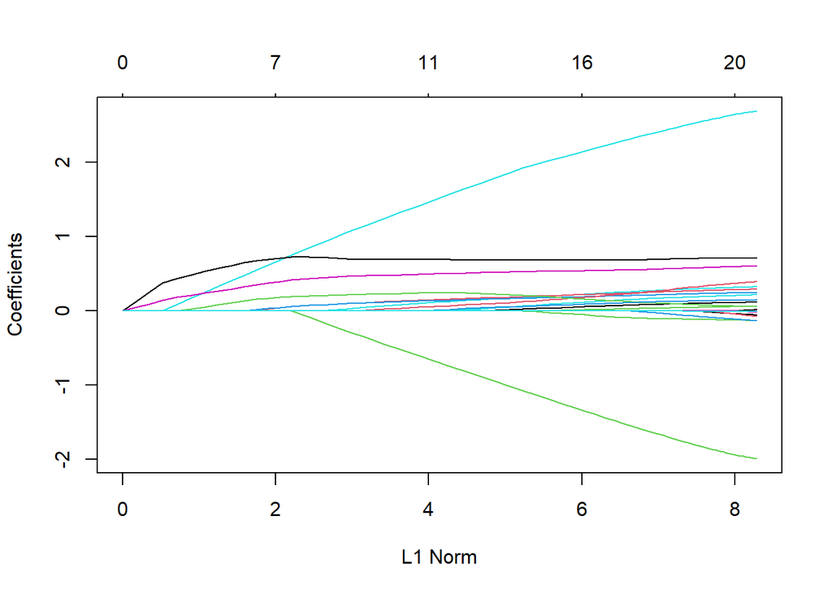

```r
lasso_model<-glmnet(Satisfaction ~ ., data=train,family = "binomial", alpha = 1)
plot(lasso_model)
```

```r
set.seed(1)
cv.out <- cv.glmnet(Satisfaction ~ ., data=train,family = "binomial", alpha = 1, K=5)
cv.out
```

```
## Call:
## cv.glmnet.formula(formula = Satisfaction ~ ., data = train, alpha = 1,
##     family = "binomial", K = 5)
##
## Model fitting options:
##     Sparse model matrix: FALSE
##     Use model.frame: FALSE
##     Number of crossvalidation folds: 10
##     Alpha: 1
##     Deviance-minimizing lambda: 0.0004450962  (+1 SE): 0.003140066
```

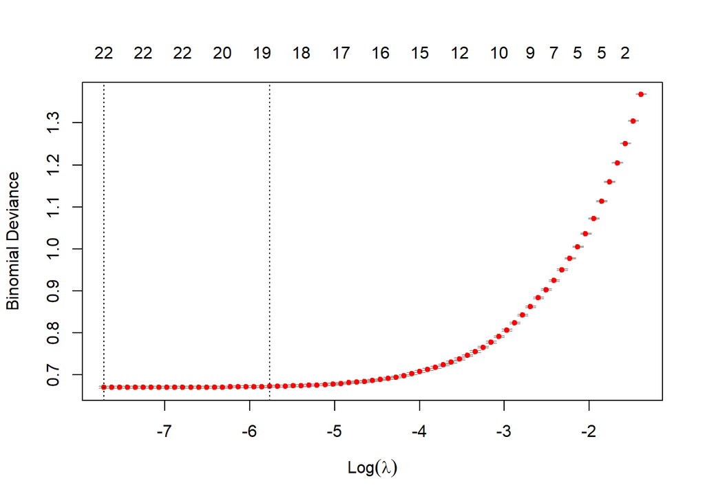

```r
plot(cv.out)
```

```r
bestlam.lasso <- cv.out$lambda.min
lasso.final <- glmnet(Satisfaction ~ .,  data=train , family = "binomial", alpha = 1, lambda = bestlam.lasso)
```

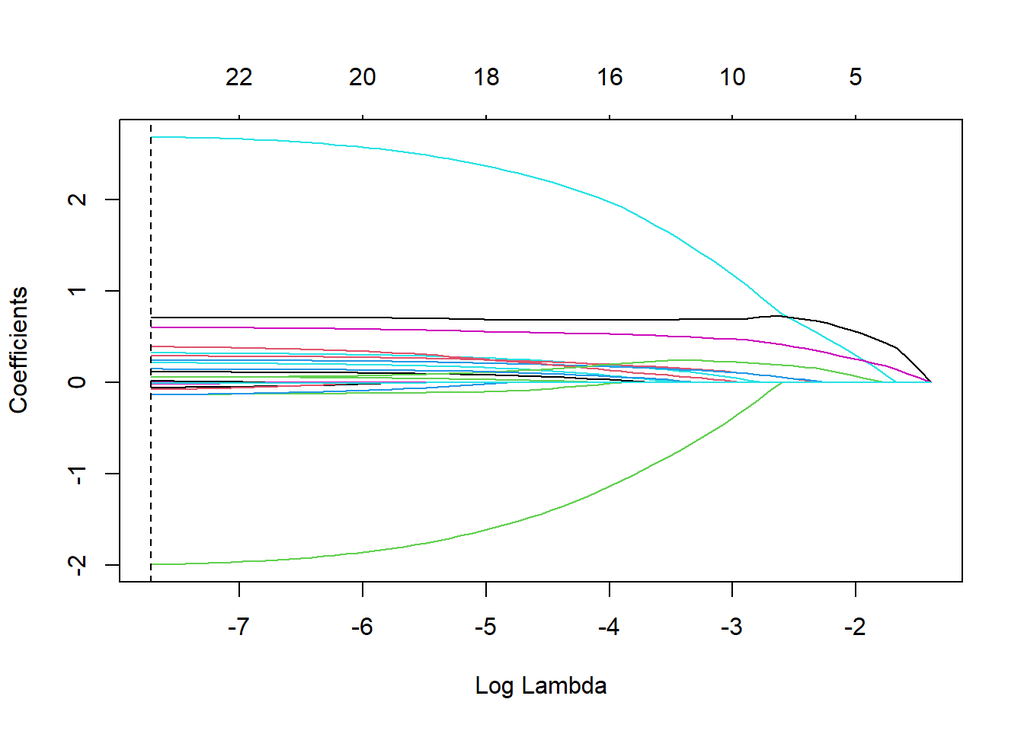

```r
plot(lasso_model, xvar = "lambda")
abline(v = log(bestlam.lasso), lwd = 1.2, lty = "dashed")
```

The Lasso solution for the selected value of lambda is:

```r
coef(lasso_model, bestlam.lasso)
```

```
## 27 x 1 sparse Matrix of class "dgCMatrix"
##                                                   s1
## (Intercept)                            -9.132062e+00
## GenderFemale                           -5.634081e-02
## GenderMale                              .
## Age                                    -7.620668e-03
## Customer.TypeFirst-time                -1.991558e+00
## Customer.TypeReturning                  .
## Type.of.TravelBusiness                  2.687473e+00
## Type.of.TravelPersonal                 -9.598434e-11
## ClassBusiness                           7.061208e-01
## ClassEconomy                            .
## ClassEconomy Plus                      -7.588678e-02
## Flight.Distance                         .
## Departure.and.Arrival.Time.Convenience -1.316778e-01
## Ease.of.Online.Booking                 -1.337745e-01
## Check.in.Service                        3.234061e-01
## Online.Boarding                         6.042403e-01
## Gate.Location                           1.562453e-02
## On.board.Service                        2.901014e-01
## Seat.Comfort                            6.177362e-02
## Leg.Room.Service                        2.454322e-01
## Cleanliness                             2.159293e-01
## Food.and.Drink                         -1.798173e-02
## In.flight.Service                       1.148255e-01
## In.flight.Wifi.Service                  3.907727e-01
## In.flight.Entertainment                 6.211173e-02
## Baggage.Handling                        1.464261e-01
## Delay                                  -4.797844e-03
```

These results show us which are the best predictors according to Lasso. We have 3 types of results:

- Positive values: they influence improving the final prediction.
- Negative values: affect worsening the final prediction.
- Neutral values: do not affect the final result.

These predictors are the most influential and should be prioritised when building a model or in further analyses.

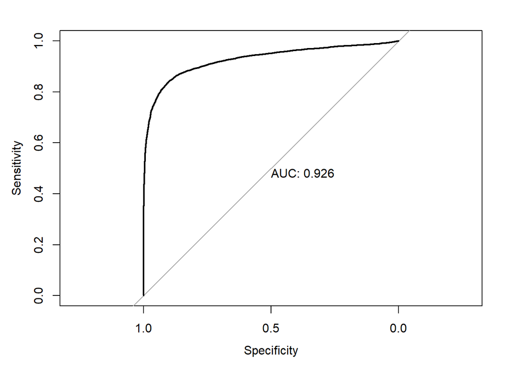

```r
lasso_model_probs <- predict(lasso_model, s = bestlam.lasso, newdata=test, type="response")
lasso_model_roc <- roc(test$Satisfaction ~ lasso_model_probs, plot=TRUE, print.auc=TRUE)
```

Roc function reports the following results with a threshold of 0.5:

```r
coords(lasso_model_roc, x=0.5, ret="all")
```

```
##           threshold specificity sensitivity  accuracy    tn   tp   fn   fp
## threshold       0.5   0.9087981   0.8314866 0.8750918 13263 9380 1901 1331
##                 npv       ppv       fdr        fpr       tpr       tnr
## threshold 0.8746373 0.8757352 0.1242648 0.09120186 0.8314866 0.9087981
##                 fnr 1-specificity 1-sensitivity 1-accuracy     1-npv     1-ppv
## threshold 0.1685134    0.09120186     0.1685134  0.1249082 0.1253627 0.1242648
##           precision    recall   youden closest.topleft
## threshold 0.8757352 0.8314866 1.740285      0.03671456
```

And the following considering the best threshold:

```r
coords(lasso_model_roc, x="best", ret="all")
```

```
##           threshold specificity sensitivity  accuracy    tn   tp   fn   fp
## threshold 0.4682895   0.8983144   0.8430104 0.8742029 13110 9510 1771 1484
##                 npv       ppv       fdr       fpr       tpr       tnr       fnr
## threshold 0.8809892 0.8650173 0.1349827 0.1016856 0.8430104 0.8983144 0.1569896
##           1-specificity 1-sensitivity 1-accuracy     1-npv     1-ppv precision
## threshold     0.1016856     0.1569896  0.1257971 0.1190108 0.1349827 0.8650173
##              recall   youden closest.topleft
## threshold 0.8430104 1.741325      0.03498571
```

```r
lasso_regression_model <- glm(Satisfaction ~ Customer.Type + Type.of.Travel + Cleanliness + In.flight.Wifi.Service + Baggage.Handling + Leg.Room.Service + On.board.Service + Food.and.Drink , data = train, family = binomial)
summary(lasso_regression_model)
```

```
##
## Call:
## glm(formula = Satisfaction ~ Customer.Type + Type.of.Travel +
##     Cleanliness + In.flight.Wifi.Service + Baggage.Handling +
##     Leg.Room.Service + On.board.Service + Food.and.Drink, family = binomial,
##     data = train)
##
## Coefficients:
##                         Estimate Std. Error z value Pr(>|z|)
## (Intercept)            -7.350581   0.054537 -134.78   <2e-16 ***
## Customer.TypeReturning  2.255236   0.023200   97.21   <2e-16 ***
## Type.of.TravelPersonal -3.349495   0.024187 -138.48   <2e-16 ***
## Cleanliness             0.486820   0.009464   51.44   <2e-16 ***
## In.flight.Wifi.Service  0.423184   0.007081   59.77   <2e-16 ***
## Baggage.Handling        0.272888   0.009495   28.74   <2e-16 ***
## Leg.Room.Service        0.249181   0.007705   32.34   <2e-16 ***
## On.board.Service        0.429938   0.008577   50.12   <2e-16 ***
## Food.and.Drink          0.008420   0.009154    0.92    0.358
## ---
## Signif. codes:  0 '***' 0.001 '**' 0.01 '*' 0.05 '.' 0.1 ' ' 1
##
## (Dispersion parameter for binomial family taken to be 1)
##
##     Null deviance: 141833  on 103611  degrees of freedom
## Residual deviance:  80323  on 103603  degrees of freedom
## AIC: 80341
##
## Number of Fisher Scoring iterations: 5
```

From this model we can see that the best predictors belong to four specific classes: Customer and Travel Type, Comfort and Cleanliness, Airport Services and On-board services.

## 8.2 Ridge Model

I will now implement the ridge model to evaluate the best predictors. I will use cross validation to find the best lambda value. The procedure is very similar to the lasso model but we change the value of alpha from 1 to zero. Ridge is based on calculating the sum of the squares of the coefficients.

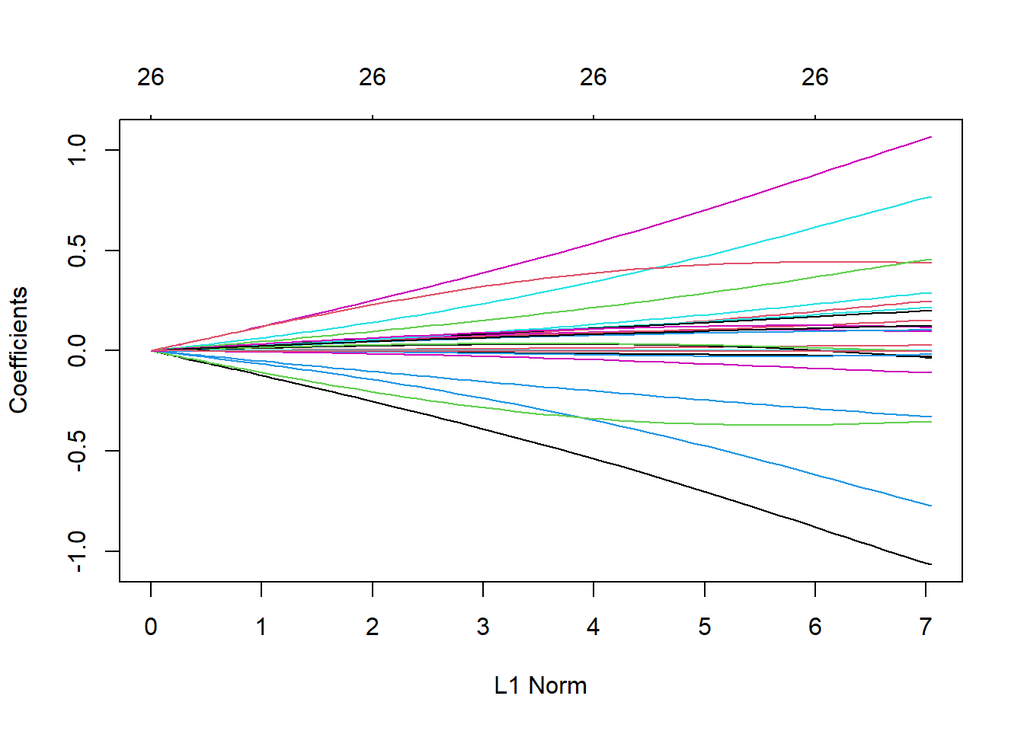

```r
ridge_model<-glmnet(Satisfaction ~ ., data=train, family = "binomial", alpha = 0)
plot(ridge_model)
```

```r
set.seed(1)
cv.out <- cv.glmnet(Satisfaction ~ ., data=train,family = "binomial", alpha = 0, K=5)
```

```r
cv.out
```

```
## Call:
## cv.glmnet.formula(formula = Satisfaction ~ ., data = train, alpha = 0,
##     family = "binomial", K = 5)
##
## Model fitting options:
##     Sparse model matrix: FALSE
##     Use model.frame: FALSE
##     Number of crossvalidation folds: 10
##     Alpha: 0
##     Deviance-minimizing lambda: 0.02488449  (+1 SE): 0.02731069
```

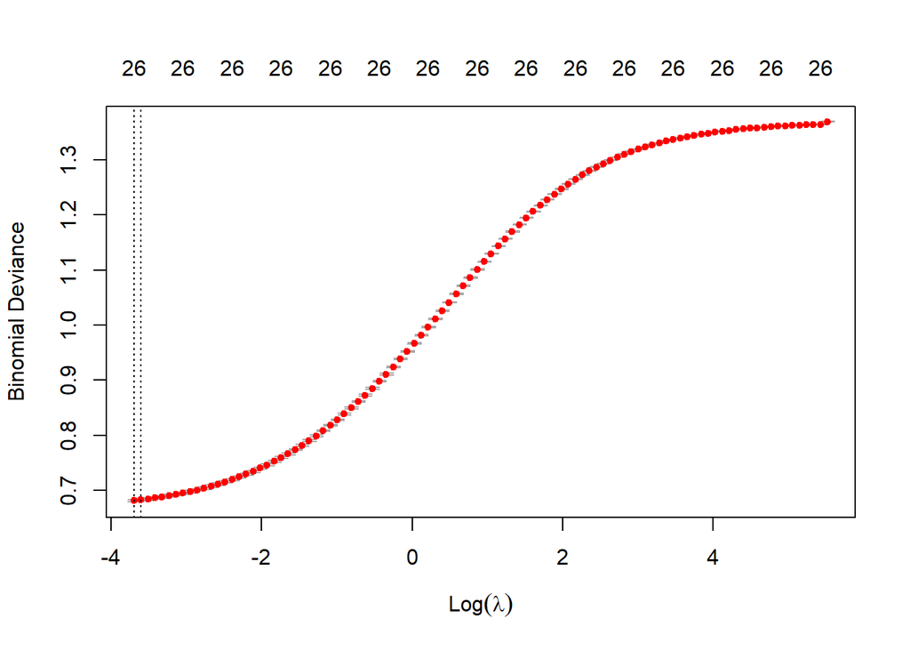

```r
plot(cv.out)
```

```r
bestlam_ridge <- cv.out$lambda.min

ridge_final <- glmnet(Satisfaction ~ .,  data=train , family = "binomial", alpha = 0, lambda = bestlam_ridge)
```

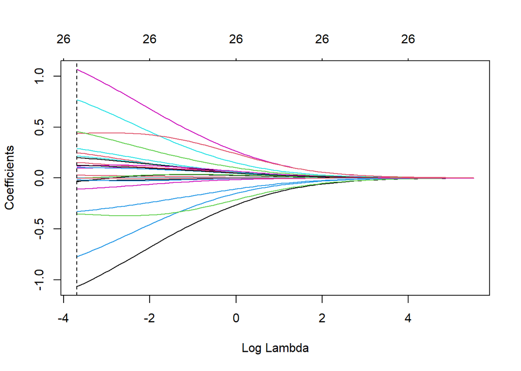

```r
plot(ridge_model, xvar = "lambda")
abline(v = log(bestlam_ridge), lwd = 1.2, lty = "dashed")
```

Ridge regression does not select a subset of predictors. Ridge regression includes all predictors p but all coefficients shrink towards zero. The idea is that reducing the coefficients reduces the complexity of the model and reduces the risk of overfitting, but without completely eliminating any variables.

The Ridge solution for the selected value of lambda is:

```r
coef(ridge_model, bestlam_ridge)
```

```
## 27 x 1 sparse Matrix of class "dgCMatrix"
##                                                   s1
## (Intercept)                            -7.3779278635
## GenderFemale                           -0.0274770335
## GenderMale                              0.0274446100
## Age                                    -0.0031379773
## Customer.TypeFirst-time                -0.7734412085
## Customer.TypeReturning                  0.7707214420
## Type.of.TravelBusiness                  1.0678576242
## Type.of.TravelPersonal                 -1.0664756851
## ClassBusiness                           0.4383056060
## ClassEconomy                           -0.3516225427
## ClassEconomy Plus                      -0.3301701086
## Flight.Distance                         0.0000452677
## Departure.and.Arrival.Time.Convenience -0.1094949479
## Ease.of.Online.Booking                 -0.0344166678
## Check.in.Service                        0.2496813767
## Online.Boarding                         0.4590610205
## Gate.Location                          -0.0175447145
## On.board.Service                        0.2200887856
## Seat.Comfort                            0.0951915020
## Leg.Room.Service                        0.2009601832
## Cleanliness                             0.1546334303
## Food.and.Drink                         -0.0027723248
## In.flight.Service                       0.1044120379
## In.flight.Wifi.Service                  0.2922439919
## In.flight.Entertainment                 0.1171432622
## Baggage.Handling                        0.1265310641
## Delay                                  -0.0034492618
```

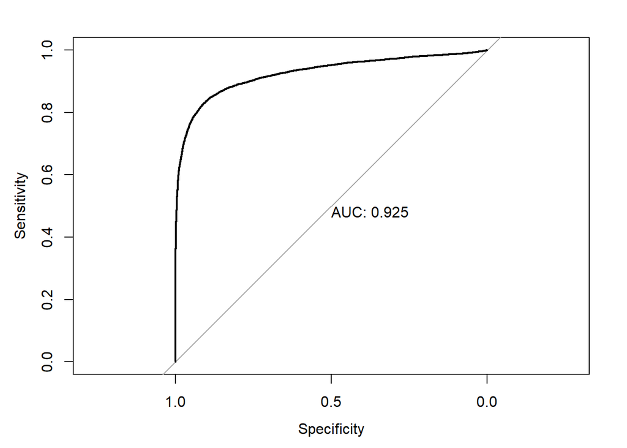

```r
ridge_model_probs <- predict(ridge_model, s = bestlam_ridge, newdata=test, type="response")
ridge_model_roc <- roc(test$Satisfaction ~ ridge_model_probs, plot=TRUE, print.auc=TRUE)
```

Roc function reports the following results with a threshold of 0.5:

```r
coords(ridge_model_roc, x=0.5, ret="all")
```

```
##           threshold specificity sensitivity  accuracy    tn   tp   fn   fp
## threshold       0.5   0.9107853   0.8267884 0.8741643 13292 9327 1954 1302
##                 npv       ppv       fdr        fpr       tpr       tnr
## threshold 0.8718352 0.8775049 0.1224951 0.08921475 0.8267884 0.9107853
##                 fnr 1-specificity 1-sensitivity 1-accuracy     1-npv     1-ppv
## threshold 0.1732116    0.08921475     0.1732116  0.1258357 0.1281648 0.1224951
##           precision    recall   youden closest.topleft
## threshold 0.8775049 0.8267884 1.737574      0.03796153
```

And the following considering the best threshold:

```r
coords(ridge_model_roc, x="best", ret="all")
```

```
##           threshold specificity sensitivity  accuracy    tn   tp   fn   fp
## threshold  0.496492   0.9092778   0.8286499 0.8741256 13270 9348 1933 1324
##                npv      ppv      fdr        fpr       tpr       tnr       fnr
## threshold 0.872854 0.875937 0.124063 0.09072221 0.8286499 0.9092778 0.1713501
##           1-specificity 1-sensitivity 1-accuracy    1-npv    1-ppv precision
## threshold    0.09072221     0.1713501  0.1258744 0.127146 0.124063  0.875937
##              recall   youden closest.topleft
## threshold 0.8286499 1.737928      0.03759136
```

We can also try to fit a logistic regression model choosing the predictors suggested by Ridge

```r
ridge_regression_model <- glm(Satisfaction ~ Customer.Type + Type.of.Travel + Class + Check.in.Service + Online.Boarding + Seat.Comfort+ Ease.of.Online.Booking + Leg.Room.Service + In.flight.Wifi.Service + Cleanliness , data = train, family = binomial)
summary(ridge_regression_model)
```

```
##
## Call:
## glm(formula = Satisfaction ~ Customer.Type + Type.of.Travel +
##     Class + Check.in.Service + Online.Boarding + Seat.Comfort +
##     Ease.of.Online.Booking + Leg.Room.Service + In.flight.Wifi.Service +
##     Cleanliness, family = binomial, data = train)
##
## Coefficients:
##                         Estimate Std. Error  z value Pr(>|z|)
## (Intercept)            -6.852940   0.059357 -115.454  < 2e-16 ***
## Customer.TypeReturning  1.692281   0.025642   65.996  < 2e-16 ***
## Type.of.TravelPersonal -2.540608   0.028423  -89.385  < 2e-16 ***
## ClassEconomy           -0.908800   0.023388  -38.858  < 2e-16 ***
## ClassEconomy Plus      -1.020082   0.039495  -25.828  < 2e-16 ***
## Check.in.Service        0.372177   0.008073   46.100  < 2e-16 ***
## Online.Boarding         0.576644   0.009455   60.990  < 2e-16 ***
## Seat.Comfort            0.055389   0.010041    5.516 3.46e-08 ***
## Ease.of.Online.Booking -0.253924   0.009373  -27.092  < 2e-16 ***
## Leg.Room.Service        0.422329   0.007600   55.568  < 2e-16 ***
## In.flight.Wifi.Service  0.498733   0.010612   46.995  < 2e-16 ***
## Cleanliness             0.254074   0.009554   26.594  < 2e-16 ***
## ---
## Signif. codes:  0 '***' 0.001 '**' 0.01 '*' 0.05 '.' 0.1 ' ' 1
##
## (Dispersion parameter for binomial family taken to be 1)
##
##     Null deviance: 141833  on 103611  degrees of freedom
## Residual deviance:  73254  on 103600  degrees of freedom
## AIC: 73278
##
## Number of Fisher Scoring iterations: 5
```

From this model we can see that the best predictors belong to four specific classes: Customer and Travel Type, Comfort and Cleanliness, Airport Services and On-board services.

# 9 Discriminant Analysis

Finally, let us do a discriminant analysis using two techniques:

- Linear Discriminant Analysis (LDA)
- Quadratic Discriminant Analysis (QDA).

These are statistical techniques used for classification. LDA assumes that the predictor variables (features) are normally distributed within each class and that all classes share the same covariance matrix. The objective of LDA is to find a linear combination of variables that maximises the separation between classes.

QDA is similar to LDA, but relaxes the assumption of the common covariance matrix. In QDA, each class can have its own covariance matrix. This allows QDA to have a quadratic decision frontier, instead of a linear one.

Let us apply the two techniques to the ‘Best_Model’ model implemented above.

## 9.1 LDA - Linear discriminant analysis

```r
best_model <- Satisfaction ~ Customer.Type + Type.of.Travel + Class + Gate.Location + On.board.Service + Baggage.Handling + Check.in.Service + Online.Boarding + Food.and.Drink + In.flight.Service + In.flight.Wifi.Service + In.flight.Entertainment + Seat.Comfort +  Leg.Room.Service + Cleanliness
```

```r
lda_step <- lda(best_model, data = train)
lda_step
```

```
## Call:
## lda(best_model, data = train)
##
## Prior probabilities of groups:
##         0         1
## 0.5658707 0.4341293
##
## Group means:
##   Customer.TypeReturning Type.of.TravelPersonal ClassEconomy ClassEconomy Plus
## 0              0.7538504             0.49144650    0.6435503        0.09728642
## 1              0.8998244             0.07189702    0.1934372        0.04137302
##   Gate.Location On.board.Service Baggage.Handling Check.in.Service
## 0      2.978203         3.019972         3.376541         3.043288
## 1      2.970098         3.851982         3.969587         3.649385
##   Online.Boarding Food.and.Drink In.flight.Service In.flight.Wifi.Service
## 0        2.661101       2.956798          3.391806               2.398663
## 1        4.026678       3.526289          3.969698               3.160201
##   In.flight.Entertainment Seat.Comfort Leg.Room.Service Cleanliness
## 0                2.889291     3.037693         2.990381    2.929884
## 1                3.964607     3.966453         3.820924    3.741624
##
## Coefficients of linear discriminants:
##                                 LD1
## Customer.TypeReturning   1.18031651
## Type.of.TravelPersonal  -1.58341072
## ClassEconomy            -0.48504013
## ClassEconomy Plus       -0.53822773
## Gate.Location           -0.06855572
## On.board.Service         0.13405539
## Baggage.Handling         0.07322145
## Check.in.Service         0.15105577
## Online.Boarding          0.28403204
## Food.and.Drink          -0.01962291
## In.flight.Service        0.06162924
## In.flight.Wifi.Service   0.16223491
## In.flight.Entertainment  0.08593324
## Seat.Comfort             0.03813286
## Leg.Room.Service         0.12577085
## Cleanliness              0.10919954
```

```r
lda_pred <- predict(lda_step, newdata=test)
lda_pred_class <- lda_pred$class

table(preds=lda_pred_class, true=testY1)
```

```
##      true
## preds     0     1
##     0 13099  1874
##     1  1495  9407
```

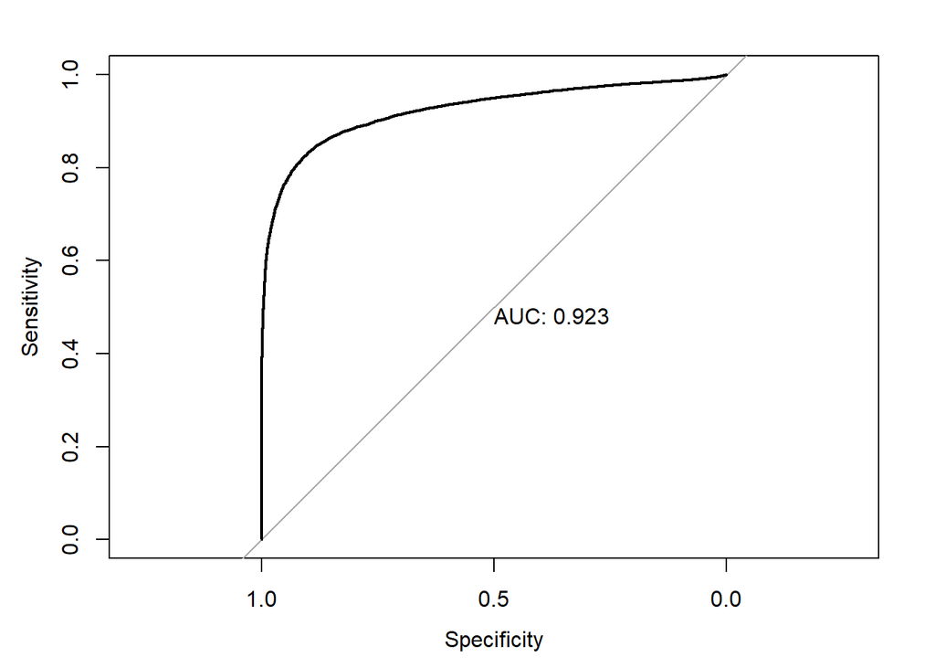

```r
lda_roc<-roc(test$Satisfaction ~ lda_pred$posterior[,2], plot=TRUE, print.auc=TRUE)
```

```r
coords(lda_roc,x=0.5, ret="all")
```

```
##           threshold specificity sensitivity  accuracy    tn   tp   fn   fp
## threshold       0.5   0.8975606     0.83388 0.8697971 13099 9407 1874 1495
##                 npv       ppv       fdr       fpr     tpr       tnr     fnr
## threshold 0.8748414 0.8628692 0.1371308 0.1024394 0.83388 0.8975606 0.16612
##           1-specificity 1-sensitivity 1-accuracy     1-npv     1-ppv precision
## threshold     0.1024394       0.16612  0.1302029 0.1251586 0.1371308 0.8628692
##            recall   youden closest.topleft
## threshold 0.83388 1.731441      0.03808968
```

```r
coords(lda_roc, x="best", ret="all")
```

```
##           threshold specificity sensitivity  accuracy    tn   tp   fn   fp
## threshold 0.5446188   0.9119501   0.8208492 0.8722319 13309 9260 2021 1285
##                npv       ppv       fdr        fpr       tpr       tnr       fnr
## threshold 0.868167 0.8781413 0.1218587 0.08804988 0.8208492 0.9119501 0.1791508
##           1-specificity 1-sensitivity 1-accuracy    1-npv     1-ppv precision
## threshold    0.08804988     0.1791508  0.1277681 0.131833 0.1218587 0.8781413
##              recall   youden closest.topleft
## threshold 0.8208492 1.732799      0.03984779
```

## 9.2 QDA - Quadratic discriminant analysis

```r
qda_step <- qda(best_model, data = train)
qda_step
```

```
## Call:
## qda(best_model, data = train)
##
## Prior probabilities of groups:
##         0         1
## 0.5658707 0.4341293
##
## Group means:
##   Customer.TypeReturning Type.of.TravelPersonal ClassEconomy ClassEconomy Plus
## 0              0.7538504             0.49144650    0.6435503        0.09728642
## 1              0.8998244             0.07189702    0.1934372        0.04137302
##   Gate.Location On.board.Service Baggage.Handling Check.in.Service
## 0      2.978203         3.019972         3.376541         3.043288
## 1      2.970098         3.851982         3.969587         3.649385
##   Online.Boarding Food.and.Drink In.flight.Service In.flight.Wifi.Service
## 0        2.661101       2.956798          3.391806               2.398663
## 1        4.026678       3.526289          3.969698               3.160201
##   In.flight.Entertainment Seat.Comfort Leg.Room.Service Cleanliness
## 0                2.889291     3.037693         2.990381    2.929884
## 1                3.964607     3.966453         3.820924    3.741624
```

```r
qda_pred <- predict(qda_step, testX)
qda_pred_class <- qda_pred$class
table(preds=qda_pred_class, true=testY1)
```

```
##      true
## preds     0     1
##     0 13142  2341
##     1  1452  8940
```

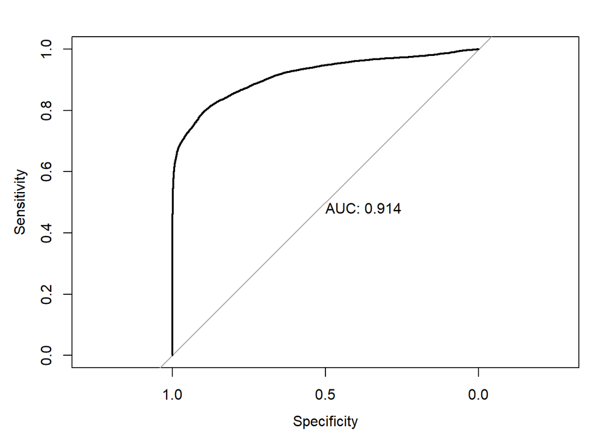

```r
qda_roc <- roc (test$Satisfaction ~ qda_pred$posterior[,2], plot=TRUE, print.auc=TRUE )
```

```r
coords(qda_roc,x=0.5, ret="all")
```

```
##           threshold specificity sensitivity  accuracy    tn   tp   fn   fp
## threshold       0.5   0.9005071   0.7924829 0.8534106 13142 8940 2341 1452
##                 npv       ppv       fdr        fpr       tpr       tnr
## threshold 0.8488019 0.8602771 0.1397229 0.09949294 0.7924829 0.9005071
##                 fnr 1-specificity 1-sensitivity 1-accuracy     1-npv     1-ppv
## threshold 0.2075171    0.09949294     0.2075171  0.1465894 0.1511981 0.1397229
##           precision    recall  youden closest.topleft
## threshold 0.8602771 0.7924829 1.69299      0.05296218
```

```r
coords(qda_roc, x="best", ret="all")
```

```
##           threshold specificity sensitivity  accuracy    tn   tp   fn   fp
## threshold 0.4861047   0.8987255   0.7945218 0.8532947 13116 8963 2318 1478
##                 npv       ppv       fdr       fpr       tpr       tnr       fnr
## threshold 0.8498121 0.8584427 0.1415573 0.1012745 0.7945218 0.8987255 0.2054782
##           1-specificity 1-sensitivity 1-accuracy     1-npv     1-ppv precision
## threshold     0.1012745     0.2054782  0.1467053 0.1501879 0.1415573 0.8584427
##              recall   youden closest.topleft
## threshold 0.7945218 1.693247      0.05247783
```

# 10 Conclusions